# POLISCI 251A Homework 1 Solutions

June 26, 2018

This chunk is useful to define global options. Don’t worry about now, just do not modify it.

Follow the instructions and write your answer in each chunk:

**HINT: Everytime that you write a new piece of code in each chunk Knit your document to check that it runs smoothly.**

**Remember to comment your code when necessary**

## 1. R basics (40 points)

### 1.1 Creating vectors (5 points)

In class we introduced vectors as the workhorse for R. Remember that to create a vector we used the ‘c()’ function and to name an object we use the ‘<-’ operator. Write an object called ‘ages’ containing the following numbers: 13, 42, 56, 78, 99, 100

```r
ages <- c(13,42,56,78,99,100)
```

#### 1.1.1

Use the ‘length()’ function to compute the number of elements in ‘ages’

```r
length(ages)
```

```
## [1] 6
```

#### 1.1.2

Change the first element of the vector ‘ages’ to 14.

*Hint: use square brackets to retrieve the first element of the vector, then assign the new value using the ‘<-’ operator*

```r
ages[1] <- 14
```

### 1.2 Naming vectors (5 points)

So far we have only created ‘unnamed vectors’, however it is also possible to store some metadata by naming each element of the vector. To do so, we use the function ‘names(’your vector’)‘. Note that ’your vector’ only stands here for the name of the object you created. Follow the instructions in the next chunk to name your vector ‘ages’

```r
### First: Create a vector called 'names_ages', containing the following elements:
##"louis", "maria", "ana", "elisa", "karl", "mark"
## Note that this is a vector of characters
names_ages <- c("louis", "maria", "ana", "elisa", "karl", "mark")
## Second: Use this vector to name the vector 'ages' using the function names()
## Hint: Look up for the function names in help or type ?names in the console
names(ages) <- names_ages
## Print the vector ages. What do you notice now?
ages
```

```
## louis maria   ana elisa  karl  mark
##    14    42    56    78    99   100
```

### 1.3 Sequences and functions with vectors (10 points)

Sometimes, if we are working with a sequence of number it is easier to use the operator ‘:’. For example, by typing c(1:10) in the console we can create all the elements from 1 to 10.

Using the ‘:’ operator create a vector called ‘seq1’ containing the elements from 1 to 100

```r
seq1 <- c(1:100)
```

Another way to create a sequence is using the function ‘seq()’. The advantage of this function is that it allow us to skip some elements.

```r
seq(from = 1, to = 10, by = 2)
```

```
## [1] 1 3 5 7 9
```

What do you notice about this sequence?

**Answer:** This sequence has increments of 2.

#### 1.3.1

Create an object called seq2 that goes from 1 to 100 with increments of 3

```r
seq2 <- seq(from = 1, to = 100, by = 3)
```

#### 1.3.2

Now, we can use these vectors to apply a function or an operation. This is a nice feature of R because you don’t have to repeat the same operation to each element. For example, we can multiply all the elements of seq1 by 2 using seq1*2.

Create a new object called seq3 that divides all the elements of seq2 by 2:

```r
seq3 <- seq2/2
### Print seq3
seq3
```

```
##  [1]  0.5  2.0  3.5  5.0  6.5  8.0  9.5 11.0 12.5 14.0 15.5 17.0 18.5 20.0
## [15] 21.5 23.0 24.5 26.0 27.5 29.0 30.5 32.0 33.5 35.0 36.5 38.0 39.5 41.0
## [29] 42.5 44.0 45.5 47.0 48.5 50.0
```

### 1.4 Logical vectors (5 points)

In class we also talked about logical vectors. Those are vectors that contain boolean expressions (TRUE, FALSE). Here we are going to use the object ‘ages’ that you created above. Using a logical vector and [], retrieve all elements larger than 50. *Hint: We did a very simple problem in the class code.*

```r
ages[c(FALSE, FALSE, TRUE, TRUE, TRUE, TRUE)]
```

```
##   ana elisa  karl  mark
##    56    78    99   100
```

### 1.5 Subsetting vectors (10 points)

Other way to subset vectors is by using the comparison operators (‘<’, ‘>’, ‘<=’, ‘=>’, ‘==’). Here we are going to use object ‘seq1’ that you created above.

Using comparison operators retrieve all elements from ‘seq1’ smaller than 20 or larger than 80. *Hint: Remember to use [] as we did in class*

```r
seq1[seq1<20 | seq1>80]
```

```
##  [1]   1   2   3   4   5   6   7   8   9  10  11  12  13  14  15  16  17
## [18]  18  19  81  82  83  84  85  86  87  88  89  90  91  92  93  94  95
## [35]  96  97  98  99 100
```

Using comparison operators retrieve all elements from ‘seq1’ that are divisible by 2. *Hint: A number is divisible by 2 if its reminder is equals to 0. To get the remminder we use the ‘%%’ operator*

```r
seq1[seq1%%2==0]
```

```
##  [1]   2   4   6   8  10  12  14  16  18  20  22  24  26  28  30  32  34
## [18]  36  38  40  42  44  46  48  50  52  54  56  58  60  62  64  66  68
## [35]  70  72  74  76  78  80  82  84  86  88  90  92  94  96  98 100
```

Using comparison operators retrieve all elements from ‘seq1’ that are divisible by 2 and larger or equal than 50 .

```r
seq1[seq1%%2==0 & seq1>=50]
```

```
##  [1]  50  52  54  56  58  60  62  64  66  68  70  72  74  76  78  80  82
## [18]  84  86  88  90  92  94  96  98 100
```

### 1.6 Matrices (5 points)

An other important data type in R are matrices. You can think about a matrix as a multidimensional vector. In this case, dimensions are rows and columns.

We use the function ‘matrix()’ to create a matrix. Take a look to this function in the help window.

Now, let’s create a matrix together:

```r
### Run this
my_mat = matrix(
   c(2, 4, 3, 1, 5, 7), # the data elements
   nrow=2,              # number of rows
   ncol=3,              # number of columns
   byrow = TRUE)        # fill matrix by rows

### print my_mat
my_mat
```

```
##      [,1] [,2] [,3]
## [1,]    2    4    3
## [2,]    1    5    7
```

We can explore the dimensions of this matrix by using the function ‘dim()’. Run this function using ‘my_mat’ as argument. Note that this returns a vector with the number of rows and the number of columns

```r
dim(my_mat)
```

```
## [1] 2 3
```

#### 1.6.1 Exploring a matrix

We can also use [] to explore elements within a matrix. The difference is that now we have to use [,] to specify the two dimensions. For example, to retrieve the element in the first row and the first column we use my_mat[1,1]

Retrieve the element at 2nd row, 3rd column:

```r
my_mat[2,3]
```

```
## [1] 7
```

## 2. Data frames (40 points)

### 2.1 Creating a data frame (10 points)

A more advance data type are data frames. Data frames allow us to combines vectors of different types. For example, the following data set contains a column vector of characters, one of numbers, and one of logical elements.

```r
### Take a look to this code and run it
world_cup_champions <- data.frame(countries= c("Brazil", "Germany", "Italy", "Argentina", "Uruguay", "France",                                      "England", "Spain"), ## Former champions
                           championships= c(5,4,4,2,2,1,1,1), ## Total championships by country
                           in_russia18 = c(TRUE, TRUE, FALSE, TRUE, TRUE, TRUE, TRUE, TRUE) ## Are playing in the Russia                           world cup?
                           )
```

Take a view to this data set by typing ‘View(world_cup_champions)’ in the console

Following the code from above, create a new data set called ‘world_cup_runner_ups’. This data set should contain the following a column character vector with the countries: Netherlands, Czechoslovakia, Hungary and Sweden. A numeric column vector with the times these teams had been runner-ups: 3,2,2, and 1 respectively. And a logical column vector specifying if they are playing in the World Cup right now: No, No, No and Yes.

```r
world_cup_runner_ups <- data.frame(countries= c("Netherlands", "Czechoslovakia", "Hungary", "Sweden"),
                           runners= c(3,2,2,1),
                           in_russia18 = c(FALSE, FALSE, FALSE, TRUE)
                           )
```

### 2.2 Exploring a dataset (10 points)

Using [] get the element in the first column and first row of ‘world_cup_runner_ups’

```r
world_cup_runner_ups[1,1]
```

```
## [1] Netherlands
## Levels: Czechoslovakia Hungary Netherlands Sweden
```

### 2.2.1

With data frames we can use the dollar sign operator to retrieve full columns. For example, to retrieve the countries from the first data set we could use ‘world_cup_champions$countries’

Using this operator retrieve the column ‘in_russia18’ from the data set ‘world_cup_runner_ups’

```r
world_cup_runner_ups$in_russia18
```

```
## [1] FALSE FALSE FALSE  TRUE
```

### 2.2.2

Get the total number of former runner ups that are playing in the Russia World Cup by using the function sum() and the column retrieved above as an argument.

```r
sum(world_cup_runner_ups$in_russia18)
```

```
## [1] 1
```

### 2.3 Factors (10 points)

Perhaps you have noticed that the column ‘countries’ is not really a character vector. Somehow, R transformed it into factors. What are these? Factors represent categorical data. They are stored as integers associated with labels and they can be ordered or unordered. While factors look (and often behave) like character vectors, they are actually treated as integer vectors by R. So you need to be very careful when treating them as strings.

Once created, factors can only contain a pre-defined set of values, known as levels. By default, R always sorts levels in alphabetical order. For instance, if you have a factor with 2 levels:

```r
### Run this
sex <- factor(c("male", "female", "female", "male"))
```

R will assign 1 to the level “female” and 2 to the level “male” (because f comes before m, even though the first element in this vector is “male”). You can see this by using the function levels() and you can find the number of levels using nlevels():

```r
# Get the levels
levels(sex)
```

```
## [1] "female" "male"
```

```r
# Get the number of levels
nlevels(sex)
```

```
## [1] 2
```

Sometimes, the order of the factors does not matter, other times you might want to specify the order because it is meaningful (e.g., “low”, “medium”, “high”), it improves your visualization, or it is required by a particular type of analysis. Here, one way to reorder our levels in the sex vector would be:

```r
# Run this
sex <- factor(sex, levels = c("male", "female"))
```

### 2.4 Adding a column (10 points)

We can also use the dollar sign to add new columns to a data frame. Note that the only restriction is that the column should have the same number of observations. For example, if we want to add a new column to ‘world_cup_runner_ups’ we should do something like this: world_cup_runner_ups$new_column <- new vector

Using this logic, add a new column to the data set ‘world_cup_champions’ called ‘total_finals’ with the following elements: 7,8,6,5,2,2,1,1

```r
world_cup_champions$tota_finals <- c(7,8,6,5,2,2,1,1)
```

Explore the modified data set with View().

## 3. Download dataframes (20 points)

From Canvas download the data set `ca2006.csv` from your computer into R. `ca2006`, a slightly modified version of the 2006 House election return data from the PSCL library.

The data set contains the following variables:

- `district`: California Congressional district
- `prop_d`: proportion of votes for the Democratic candidate
- `dem_pres_2004`: proportion of two-party presidential vote for Democratic candidate in 2004 in Congressional district
- `dem_pres_2000`: proportion of two-party presidential vote for Democratic candidate in 2000 in Congressional district
- `dem_inc`: An indicator equal to 1 if the Democrat is the incumbent
- `contested`: An indicator equal to 1 if the election is contested
- `open`: An indicator equal to 1 if the election is contested

Before we start, we need to download some additional packages. Follow the following code to install the package ‘foreign’. This package allow us to read many kinds of formats (‘Minitab’, ‘S’, ‘SAS’, ‘SPSS’, ‘Stata’, ‘Systat’, ‘Weka’, ‘dBase’, …). In this case, we are going to use the function ‘read.csv’ to read comma separated variables format.

```r
#### Package
## First, install the package. Uncomment the following code and run it just once.
##Then comment it again. Remember that we only need to download the package once.
## install.packages('foreign')
## Second: Load the library
library(foreign)
```

Then, we need to set a working directory

```r
# set working directory to the folder where you stored your dataset
setwd("C://Users/Edgar/Dropbox/PhD/5_year/summer/ML_class/Homework/HW1/")

# Now, we can dowload the data. After installing the package and setting the working directory,
##uncomment the following code
ca <- read.csv("ca2006.csv")
```

### 3.1 Examining the dataset (10 points)

Explore the structure of the data using the function ‘str()’

```r
# Run this
str(ca)
```

```
## 'data.frame':    53 obs. of  7 variables:
##  $ district     : int  1 2 3 4 5 6 7 8 9 10 ...
##  $ prop_d       : num  0.692 0.337 0.389 0.481 0.749 ...
##  $ dem_pres_2004: num  0.609 0.371 0.412 0.379 0.617 ...
##  $ dem_pres_2000: num  0.571 0.353 0.43 0.378 0.633 ...
##  $ dem_inc      : int  1 0 0 0 1 1 1 1 1 1 ...
##  $ contested    : int  1 1 1 1 1 1 0 1 1 1 ...
##  $ open         : int  0 0 0 0 0 0 0 0 0 0 ...
```

How many observations are in this data set??

**Answer:** The data set has 53 observations

For large data sets you can also explore the first rows using the function ‘head()’. Display the head for ‘ca’

```r
head(ca)
```

```
##   district    prop_d dem_pres_2004 dem_pres_2000 dem_inc contested open
## 1        1 0.6921327     0.6088141     0.5714932       1         1    0
## 2        2 0.3367234     0.3707784     0.3527625       0         1    0
## 3        3 0.3894475     0.4119854     0.4296669       0         1    0
## 4        4 0.4807607     0.3788746     0.3775659       0         1    0
## 5        5 0.7492580     0.6171210     0.6332681       1         1    0
## 6        6 0.7185022     0.7142595     0.6724122       1         1    0
```

Finally, you can run a summary by using the function ‘summary()’. Display the summary for ‘ca’

```r
summary(ca)
```

```
##     district      prop_d       dem_pres_2004    dem_pres_2000
##  Min.   : 1   Min.   :0.0000   Min.   :0.3132   Min.   :0.3419
##  1st Qu.:14   1st Qu.:0.3894   1st Qu.:0.4120   1st Qu.:0.4323
##  Median :27   Median :0.6640   Median :0.5914   Median :0.5838
##  Mean   :27   Mean   :0.6220   Mean   :0.5612   Mean   :0.5760
##  3rd Qu.:40   3rd Qu.:0.7520   3rd Qu.:0.6688   3rd Qu.:0.6813
##  Max.   :53   Max.   :1.0000   Max.   :0.8724   Max.   :0.8602
##     dem_inc         contested           open
##  Min.   :0.0000   Min.   :0.0000   Min.   :0.00000
##  1st Qu.:0.0000   1st Qu.:1.0000   1st Qu.:0.00000
##  Median :1.0000   Median :1.0000   Median :0.00000
##  Mean   :0.6226   Mean   :0.8491   Mean   :0.03774
##  3rd Qu.:1.0000   3rd Qu.:1.0000   3rd Qu.:0.00000
##  Max.   :1.0000   Max.   :1.0000   Max.   :1.00000
```

We are going to use this data set in the next homework, so it is convenient that you start getting familiar with the variables. Take a moment to explore the different values from the summary.

### 3.2 Plot (10 points)

R is also an excellent tool to create graphics. Later in the quarter we’ll see some packages designed just for this purpose. For now, we can use the ‘plot()’ function native to R.

Using this function and the dollar sign operator to retrieve columns, plot the democratic vote in 2000 against the vote in 2004. Keep the vote for 2000 on the x axis. *Hint: Take look to the help window for ‘plot’*

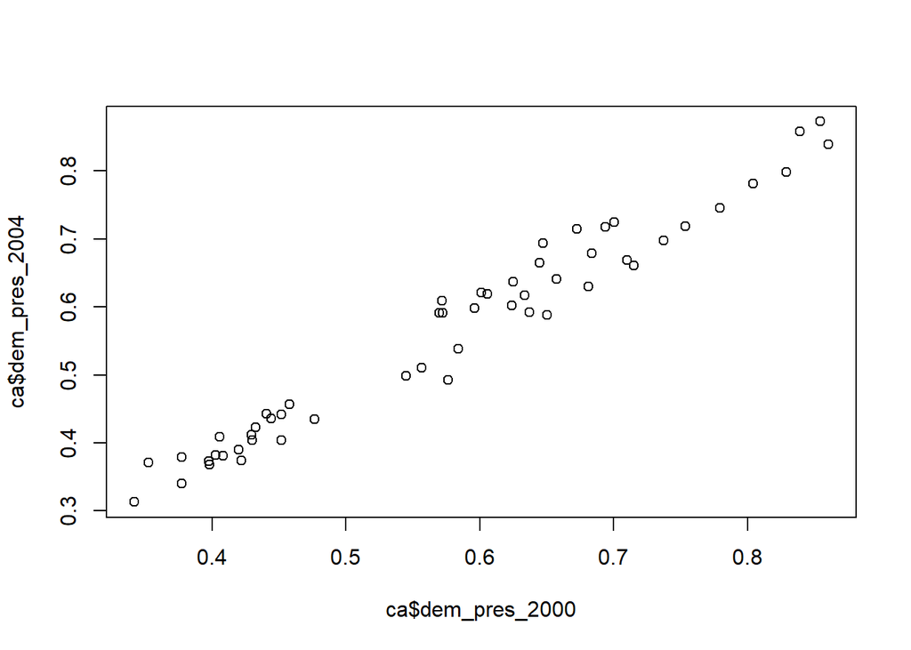

```r
plot(ca$dem_pres_2000, ca$dem_pres_2004)
```

## 4. Bonus (5 points)

Based on the readings from week 1 on two different approaches to learning, imagine that you want to share your thoughts with the world via Twitter. Below, write 3 tweets supporting or criticizing one of these articles. Remember that tweets have 140 characters or less. Also, try to direct your tweets to an educated audience that is neither too technical nor too simplistic.

**Tweet1:**

**Tweet2:**

**Tweet3:**